# Introduction to programming in R

Julia Rühle & Leone Albinati

25th-27th of November 2024

# Project Overview

In this mini-project, you will analyze real data coming from this paper https://www.nejm.org/doi/full/10.1056/NEJMoa1505917

[figure not shown]

We have two main datasets: one **“clinical”** and one **“molecular”**

- The first has information about age, gender, tumor size and other variables.
- The second dataset is coming from an RNAseq experiment, for which Fold Change and p values have already been calculated.

In this small project you will apply your skills in data manipulation and in plotting, following the basics of data visualization that we learned in the previous session. If you can, comment every line explaining what you are doing.  
When **plotting**, we will always ask you to think about what is the best type of plot to visualize your data, focusing on the most standard ones.

- **Scatterplot** (geom_point() function in ggplot)
- **Boxplot** (geom_boxplot() function in ggplot)
- **Barplot** (geom_bar() or geom_col() function in ggplot)
- **Histograms** (geom_histogram() function in ggplot)

We will start from the clinical dataset to then move to the molecular one.

# Part 1: the clinical dataset

Let’s start by **creating a new directory** in the Rcourse_2024 called mini_project. If you have not done it yet, download in this folder the two files we are going to use (ClinicalDataNoNA.csv and RNAseq.csv).

- 1. Set the working directory in the newly created folder
- 2. Load the libraries we need (tidyverse)

**Answer**

```r
# 1. set the working directory to the newly created folder
setwd("Desktop/Rcourse_2024/mini_project/") # here you have to put your path to the folder

# 2. load the tidyverse library
library(tidyverse)
```

## Exercise 1: load and explore the dataset

When approaching a new dataset, it is important to check its content to become familiar with the different variables.

- 1. Load the dataset (“ClinicalDataNoNA.csv”) and assign to an object called **clinical**: when reading it, **careful with the column names and the extension, comma separated value (csv)**.
- 2. How many rows (**observations**) and columns (**variables**) are there in the dataset?
- 3. Print the **first** and **last rows** of the dataset.
- 4. Print the **column names** of the dataset.
- 5. How many **Male and Female** patients are in the dataset (remember group_by and summarise?).
- 6. Which different **types of tumor** are in the dataset and how many observation for each type?
- 7. What is the **maximum size** of the largest part of the tumor?
- 8. What is the **average age at diagnosis**?

**Answer**

```r
# 1. read the dataset
clinical <- read.table(file = "ClinicalDataNoNA.csv", # name of the file
                       sep = ",", # the separator is a comma (the file is a .csv)
                       header = T) # it has column names

# 2. How many rows and columns in the dataset
dim(clinical) # gives both dimensions together
nrow(clinical) # gives only the number of rows
ncol(clinical) # gives only the number of columns

# 3. Print first and last rows
head(clinical) # prints the first 6 rows
tail(clinical) # prints the last 6 rows

# 4. Print the column names
colnames(clinical)

# 5. How many male and female
# We can group by the Gender and then count the numbers (with the function n())
clinical %>% group_by(Gender) %>% summarise(count=n())

# 6. How many tumor types - same as before
clinical %>% group_by(tumor_type) %>% summarise(count=n())

# 7. Maximum size of the tumor
max(clinical$tumor_size_largest)

# 8. Average age at diagnosis
mean(clinical$age_at_diagnosis)
```

## Exercise 2: cleaning the dataset

- 1. We’ve seen that some tumors are described as **Unclassified**; we are not interesting in this category and we want to remove them. Assign to a new object called **classified** the data frame without the unclassified tumors.
- 2. Moreover, we will not work on all the variables for now, and we want to remove the ones we are not using to have a tidier dataset. Create a new object called **classified_tidy** that stores only the columns tumor_type, age_at_diagnosis, Gender, tumor_size_largest, tumor_size_smallest.
- 3. Write this newly created data frame to a file named “clinical_data_tidy.txt”. Make the file tab-separated (“’” the symbol for tab seprated files), include the column names but not the rownames, don’t put quotes on the characters.

**Answer**

```r
# 1. Remove the uncalssified tumors from the dataset
# We can use the filter() function
classified <- clinical %>% filter(tumor_type!="Unclassified_Papillary_RCC")

# 2. Remove "useless" variables to tidy the dataframe
# We can use the select() function and type the name of the columns we want to keep
classified_tidy <- classified %>% select(tumor_type, age_at_diagnosis, Gender, tumor_size_largest, tumor_size_smallest)

# 3. Write the table
write.table(x = classified_tidy, # object to save
            file = "clinical_data_tidy.txt", # name to save
            quote = F,  # do not include characters in quotes
            sep = "\t", # tab separated
            row.names = FALSE, # no row names
            col.names = TRUE) # yes column names
```

## Exercise 3: type and size

Now let’s start exploring the **relationship between different variables**.  
Let’s start with largest tumor size: is there a difference between type1 and type2? We have one **categorical** (tumor_type) and one **numerical** (tumor_size_largest) variable.

**Answer**

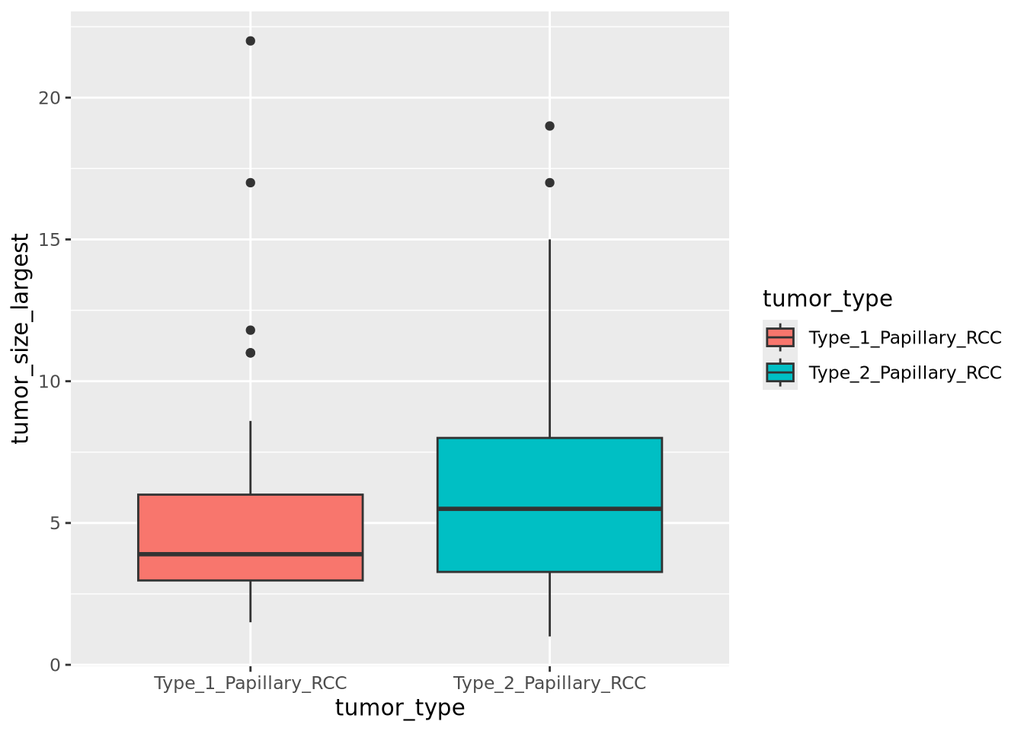

```r
# 1. Relationship between numerical and categorical variables can be easily visualized with a boxplot. the function for ggplot is geom_boxplot().

# 2. Let's plot the boxplot, filling for the tumor_type just adds the color
ggplot(classified_tidy, aes(x = tumor_type, y = tumor_size_largest, fill=tumor_type)) +
  geom_boxplot()
```

## Exercise 3.1: statistical significance

- 1. Create an object called **type1** selecting only the rows that belong to type1 tumors.
- 2. Do the same for type2 tumors and call the object **type2**.
- 3. We want to check for **distribution** of the data. What is a possible plot to visualize this type of data?
- 4. Plot the distribution of the **tumor_size_largest** variable for the two tumor types. Remember: to plot histograms use only the x inside the aesthetics, because the y will be the distribution.
- 5. Even if not completely clear, let’s consider this distribution as “normal” (if you want to be more precise, google **“shapiro test in R”**). Now we can compute the p-value using the t test - google/ask chatgpt the function to do so. Is the difference statistically significant?

**Answer**

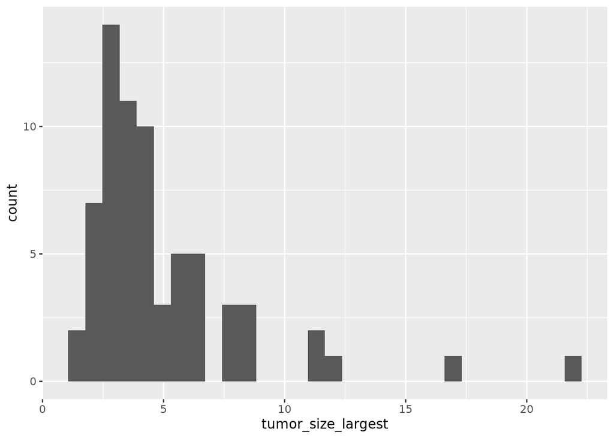

```r
# 1 and 2. Create type1 and type2 objects filtering the rows
type1 <- classified_tidy %>% filter(tumor_type=="Type_1_Papillary_RCC")
type2 <- classified_tidy %>% filter(tumor_type=="Type_2_Papillary_RCC")

# 3. Data distribution can be easily visualized with a histogram. The function for ggplot is geom_histogram().

# 4. Let's visualize the histograms for the two plots
ggplot(type1, aes(x=tumor_size_largest))+
  geom_histogram()
```

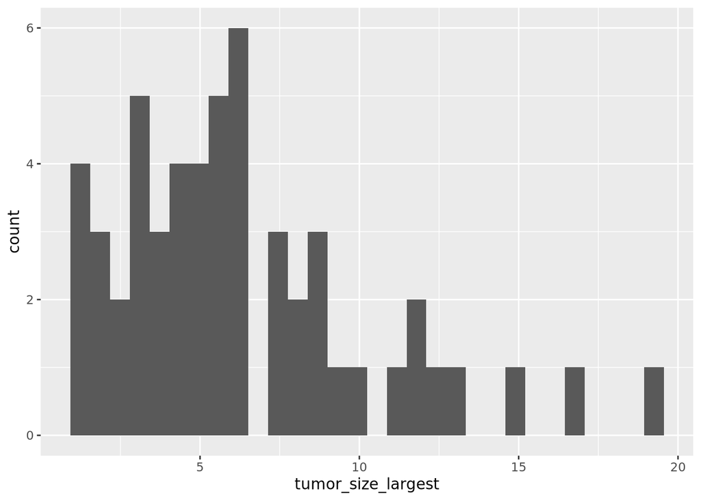

```r
ggplot(type2, aes(x=tumor_size_largest))+
  geom_histogram()
```

```r
# 5. t.test function to compute the pvalue using t-test
t.test(tumor_size_largest ~ tumor_type, data = classified_tidy)
```

```
##
##  Welch Two Sample t-test
##
## data:  tumor_size_largest by tumor_type
## t = -1.9971, df = 105.04, p-value = 0.0484
## alternative hypothesis: true difference in means between group Type_1_Papillary_RCC and group Type_2_Papillary_RCC is not equal to 0
## 95 percent confidence interval:
##  -2.750675854 -0.009890595
## sample estimates:
## mean in group Type_1_Papillary_RCC mean in group Type_2_Papillary_RCC
##                           4.938235                           6.318519
```

## Exercise 3.2: installing the ggpubr package

We can also directly compute the pvalues in the boxplot: there is a very useful package called **ggpubr** (gg pubblication ready) that helps with computing statistical tests while plotting.

- 1. Install the package ggpubr (remember the function install.packages(), the arguments must be inside quotes).
- 2. Load the package (remember the function library)

**Answer**

```r
# 1 and 2. Install and load the packages
install.packages("ggpubr")
library(ggpubr)
```

## Exercise 3.3: computing statistics on plots

Now that we have installed and loaded the package, we can compute the ttest directly on the plot.  
In this case, let’s see together how to do it. - 1. Check the help page for the function stat_compare_means(). This function can be added with a + after a ggplot and its argument method can be specified using different statistical tests. In our case we can use “t.test”. Plot the boxplot with the t-test automatically calculated. Here how to do it:

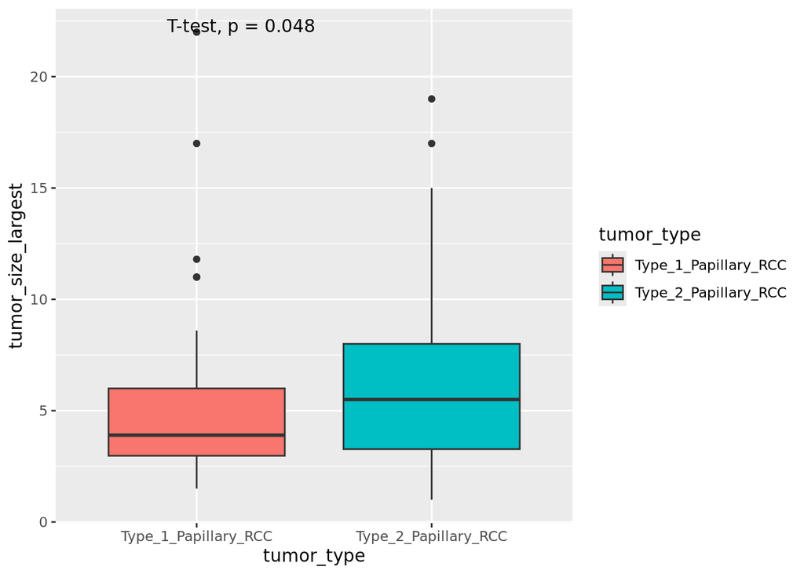

```r
# 3. Add the pval from the plot
ggplot(classified_tidy, aes(x = tumor_type, y = tumor_size_largest,fill=tumor_type)) +
  geom_boxplot()+
  stat_compare_means(method = "t.test") # we could even use different methods
```

## Exercise 4: type and age at diagnosis

Now let’s repeat what we did but for a different variable. Check the relationship between **tumor type** (one and two) and **age at diagnosis**. Assume the variable is normally distributed in the two type groups (we can compute the t-test).

1 - Plot the boxplot for age_at_diagnosis comparing the two tumor types and add the p-value of the comparison using stat_compare_means().

**Answer**

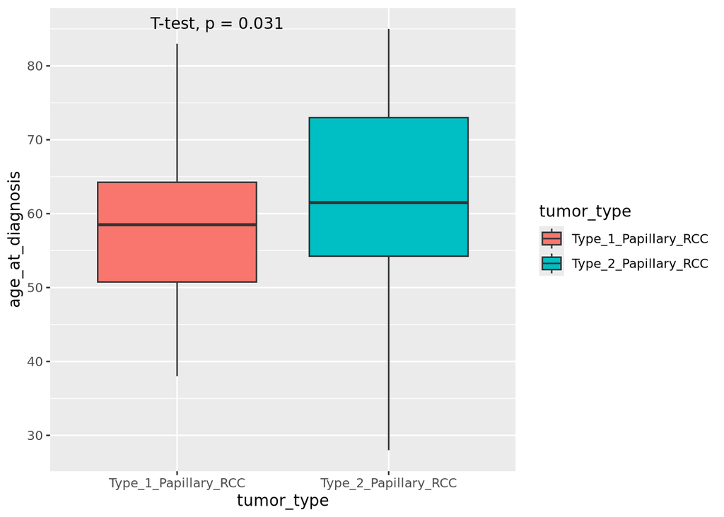

```r
# Let's repeat for the age
ggplot(classified_tidy, aes(x = tumor_type, y = age_at_diagnosis, fill=tumor_type)) +
  geom_boxplot()+
  stat_compare_means(method = "t.test")
```

## Exercise 5: relationship between size and age at diagnosis

Now let’s compare **largest size** and **age at diagnosis** for each tumor type. We already generated the data frames type1 and type2, we will use them to compare the variables inside each tumor type.

- 1. “tumor_size_largest” and “age_at_diagnosis” are two **continuous numerical variables**. Which plot would you use?
- 2. Plot the comparison between tumor_size_largest and age_at_diagnosis in the two different tumor types. Is there a clear pattern?

**Answer**

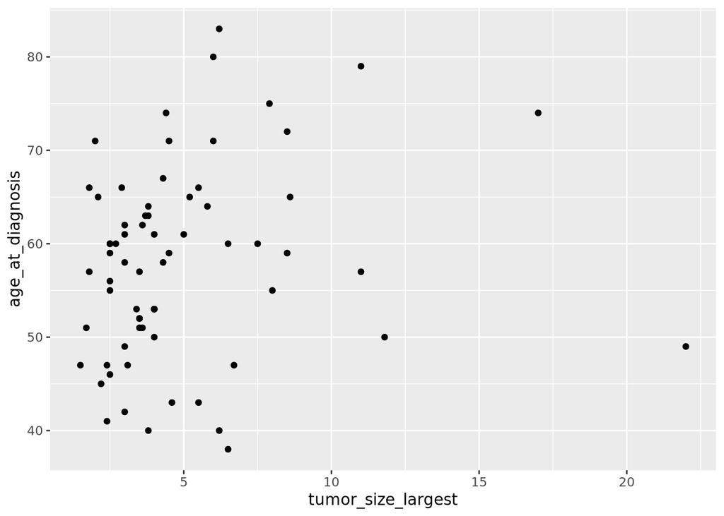

```r
# 1. Relationship between two continous numerical variables can be easily visualized with a scatterplot. The function for ggplot is geom_point().

# 2a. plot correlation for type 1
ggplot(type1,aes(x=tumor_size_largest,y=age_at_diagnosis))+
  geom_point()
```

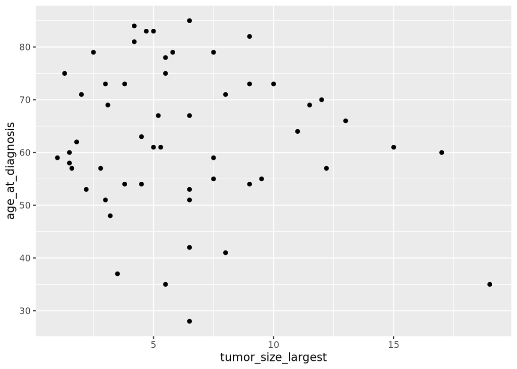

```r
# 2b. plot correlation for type 2
ggplot(type2,aes(x=tumor_size_largest,y=age_at_diagnosis))+
  geom_point()
```

```r
# The correlation between these variables is not visually clear.
```

## Exercise 5.1: regression line and statistical correlation

FYI: we can add **regression lines** and **statistical correlation** to scatterplot using the functions stat_cor() and geom_smooth(method = “lm”, se = FALSE). Check them out!

[figure not shown]

```r
ggplot(type1,aes(x=tumor_size_largest,y=age_at_diagnosis))+
  geom_point() + stat_cor()+
   geom_smooth(method = "lm", se = FALSE)
```

[figure not shown]

```r
ggplot(type2,aes(x=tumor_size_largest,y=age_at_diagnosis))+
  geom_point() + stat_cor()+
   geom_smooth(method = "lm", se = FALSE)
```

We saw that there is no significant correlation between the tumor_size_largest and the age_at_diagnosis.

## Exercise 5.2: significant statistical correlation

If you want to see two variables that are correlated significantly, check the largest and smallest tumor size.

- 1. Repeat the plot we just did but comparing rgest and smallest tumor size. Check also their correlation.

**Answer**

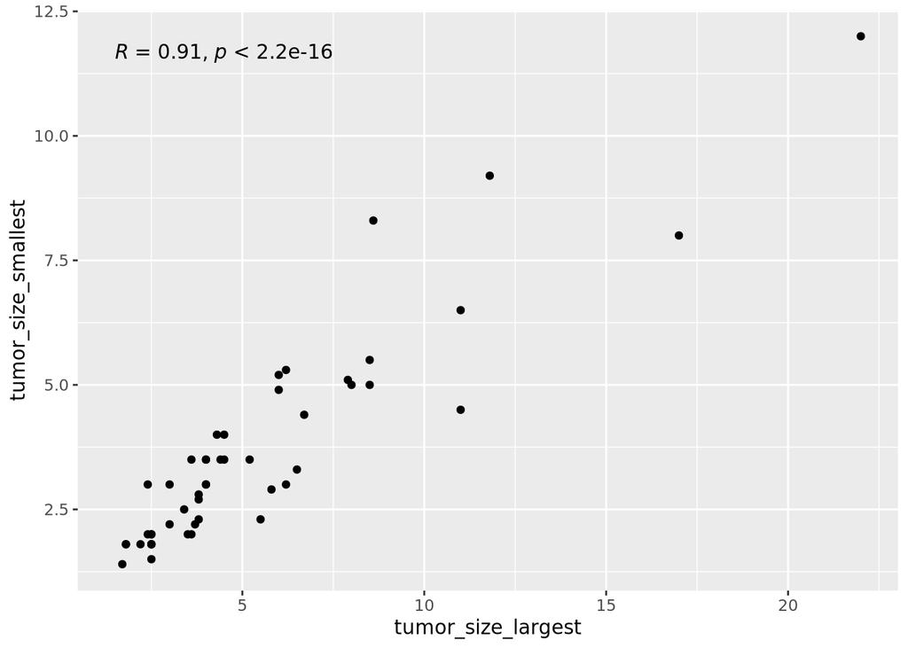

```r
# 1. plot significant correlation
ggplot(type1,aes(x=tumor_size_largest,y=tumor_size_smallest))+
  geom_point() + stat_cor()
```

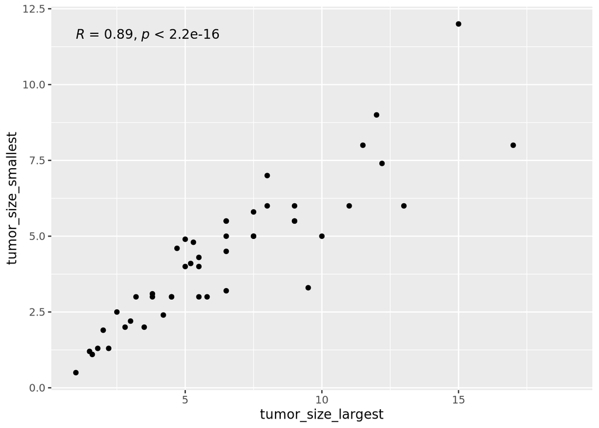

```r
ggplot(type2,aes(x=tumor_size_largest,y=tumor_size_smallest))+
  geom_point() + stat_cor()
```

## Exercise 6: comparing Gender and Type

Now let’s compare the gender and the type to see if there is a predominance of one type in a specific gender.

- 1. Create a new data frame (called **gender_type**) that stores the count for the two tumor types in Male and Female. We need to create a data frame that counts the number of observation for the different combinations (male-type1, male-type2, female-type1, female-type2). Do you remember the **group by and summarize**? Useful here.
- 2. Visualize this data: we have two **categorical** variables (Gender and tumor_type). How do we visualize them?
- 3. Plot the data. Are you able to tell if there is a preference for one of the two types in Male or Female?

**Answer**

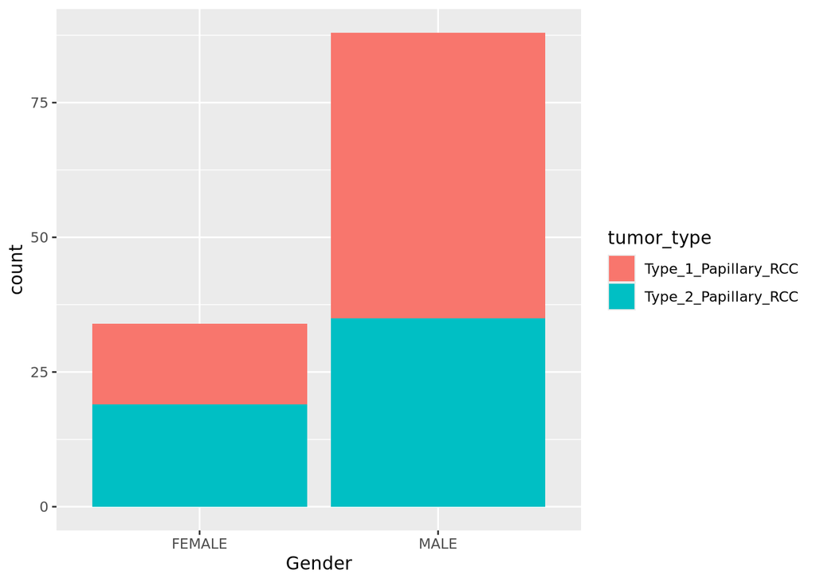

```r
# 1. let's count the number for the combinations
gender_type <- classified_tidy %>%
  group_by(Gender,tumor_type) %>%
  summarise(count=n())

# 2. Relationship between two categorical variables can be easily visualized with a barplot.
# The function for ggplot is geom_col() or geom_bar().
# The second function is a bit more complex because it requires different arguments, but allows to play a bit with the barplots.

# 3a. First option: geom_col
ggplot(gender_type,aes(x=Gender,y=count,fill=tumor_type)) +
  geom_col()
```

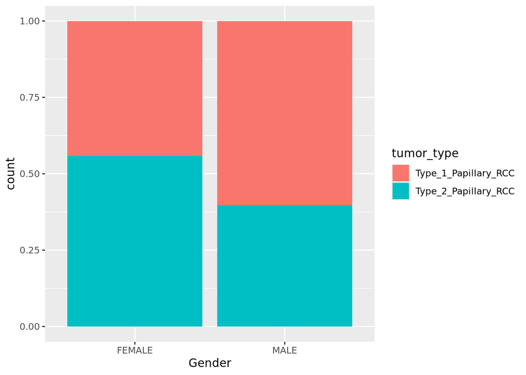

```r
# 3b. Second option: geom_bar: you can also play with the position and stat parameters
ggplot(gender_type,aes(x=Gender,y=count,fill=tumor_type)) +
  geom_bar(position = "fill",stat = "identity")
```

## Summary of Part1

- We explored the dataset, and we visualized using different plots based on the variable types.
- One categorical and one numerical: boxplot (geom_boxplot())
- Distribution of the data: histogram (geom_histogram())
- Two numerical: scatterplot (geom_point())
- Two categorical: barplot (geom_bar())

# Part 2: the RNAseq dataset

Here we introduce the second dataset of this exercise, the RNA-seq dataset. This dataset includes genes coming from multiple **bulk RNA sequencing experiments** done on both tumors from type1 and type2. From these experiments, a **Fold Change** has been calculated between the two tumor subtypes, together with a **p-value**.

## Exercise 1: Load and explore the dataset

- 1. Read the dataset **“RNAseq_FC.csv”**, and assign to the object **RNAseq**. Remember that it is a .csv file and it has column names.
- 2. Check the **first 10 rows** of the dataset. To do so check the help of the head() function.
- 3. How many genes are present in this dataset?
- 4. Remove the genes with a **fold change equal to 1** and reassign to **RNAseq**.
- 5. What is the maximum and the minimum Fold Change and to which genes do they belong? Tip: you can order the dataset and then print the first and last row.
- 6. How many genes from the **cyclin family** are in the dataset? The genes from the cyclin family all start with **CCN**. You can use grepl to subset the data frame for those genes and then count. SKIP IF TOO HARD!

**Answer**

```r
# 1. Read the dataset
RNAseq <- read.table(file = "RNAseq_FC.csv",
                     header = T,
                     sep = ",")

# 2. check the help page for the head function and then check the first 10 rows
?head()
head(RNAseq,n=10)

# 3. The genes are the observations, so to get their numbers we count the rows
nrow(RNAseq)

# 4. Remove the genes that have a FC==1
RNAseq <- RNAseq %>% filter(FC_type2vstype1!=1)

# 5. Calculate maximum and minimum fold change
# 5a. Let's order the dataset
ordered_RNA <- RNAseq %>% arrange(FC_type2vstype1)
# 5b. Select the first and last row using the head and specifying the n=1
head(ordered_RNA,n=1)
tail(ordered_RNA,n=1)

# 6. Count the genes belonging to the cyclin family
cyclin <- RNAseq %>% filter(grepl("CCN",symbol))
nrow(cyclin)
```

## Exercise 2: Log transformation of the fold change

When we work with Fold Change in RNA seq, what we normally do is to log transform it.

- 1. Check the **distribution** of the fold change - is it skewed?
- 2. Create a new column with the **log2 transformation** of the Fold Change (called **log2FC**). Google how to compute log2 in R.
- 3. Now check the **distribution** of the log2 fold change column. Is it better?

**Answer**

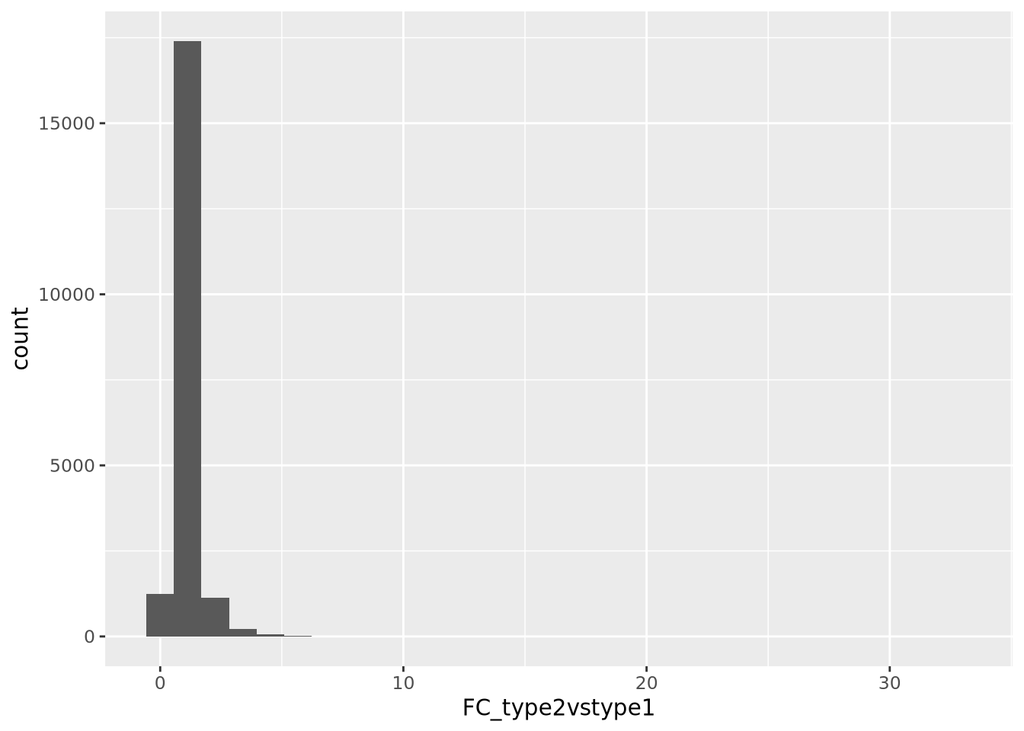

```r
# 1. To check the distribution, use a histogram
ggplot(RNAseq, aes(x=FC_type2vstype1))+
  geom_histogram()
```

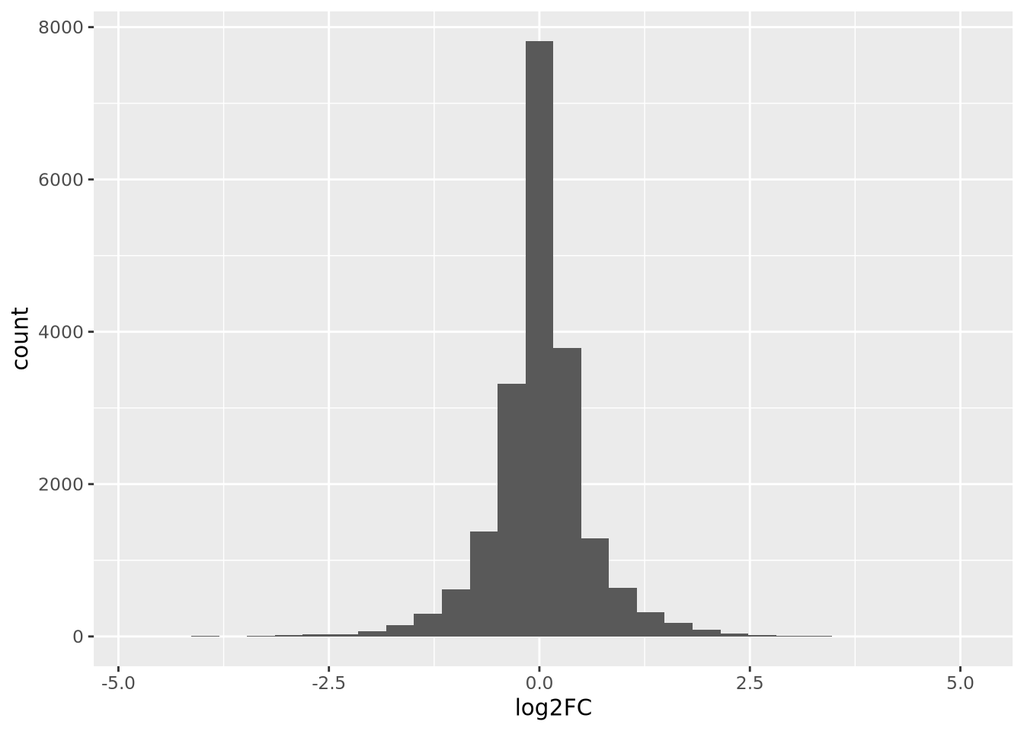

```r
# 2. Log2 transformation - the function log2()
RNAseq <- RNAseq %>% mutate(log2FC=log2(FC_type2vstype1))

# 3. plot the trasnformed data
ggplot(RNAseq, aes(x=log2FC))+
  geom_histogram()
```

## Exercise 3: Volcano plot

A very useful tool to visualize RNAseq data is to use **volcano plots**.

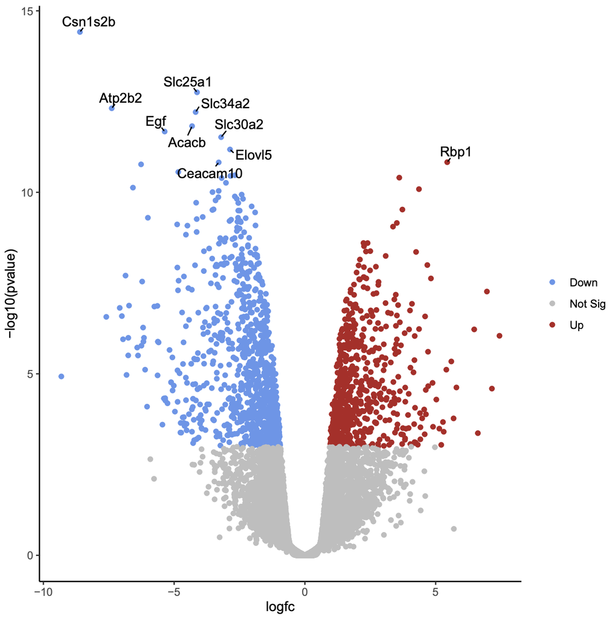

Volcano plot is a scatterplot (geom_point()) that has log2FC on the x axis and -log10(pvalue) on the y axis.

- 1. We already created the log2FC column, now let’s start create the -log10(pval) column (named **minuslog10pval**).
- 2. Now plot, the volcano plot! What goes on the x and what on the y axis?
- 3. HARD: Let’s say we want to color only the dots that have a pval < 0.0001. We can create a new column with T/F for the conditional statement pval < 0.0001 and call it **interest**.

**Answer**

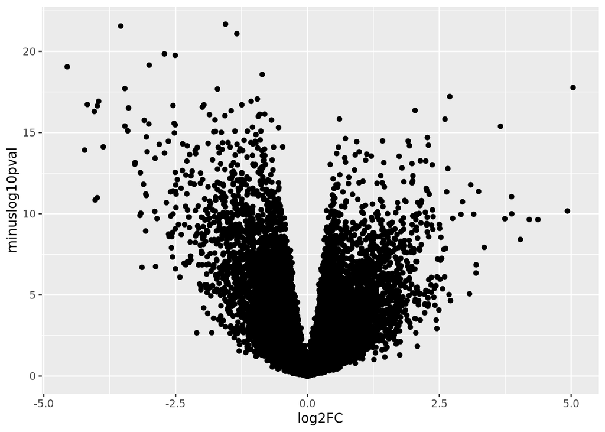

```r
# 1. Create the column storing -log10(pval)
RNAseq <- RNAseq %>%
  mutate(minuslog10pval=-log10(pval))

# 2. Plot the volcano plot!
RNAseq %>% ggplot(aes(x = log2FC,y= minuslog10pval)) + geom_point()
```

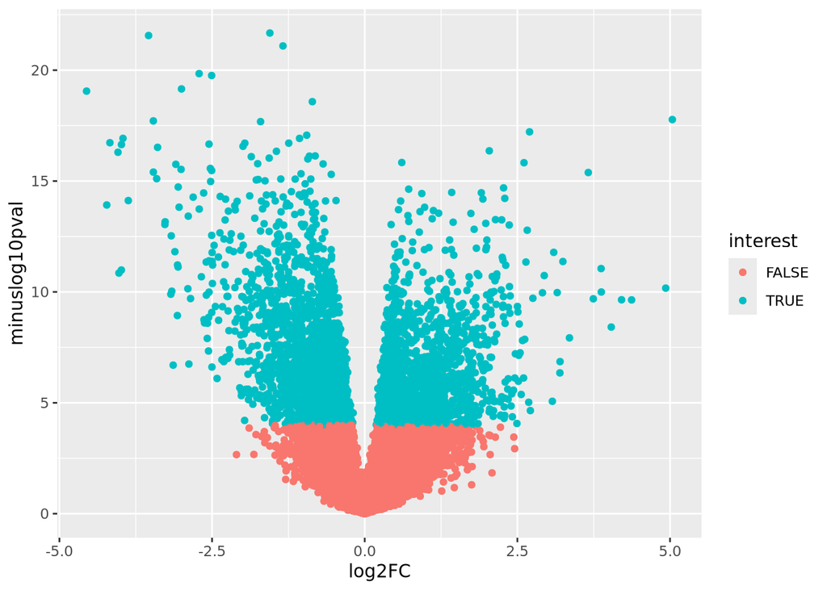

```r
# 3a. Create a T/F column that stores TRUE if pval < 0.0001
RNAseq <- RNAseq %>%
  mutate(interest=pval<0.0001)

# 3b. Plot coloring for the newly created column
RNAseq %>% ggplot(aes(x = log2FC,y= minuslog10pval,color=interest)) +
  geom_point()
```

# CONGRATS

If you made until here, congrats! If you did not, you can still try to do it after the course and use this exercise as a memorandum on how to filter, select and plot!